# SteniqJulia

# Why Julia?

## What happens when you use Julia?

A. Edelman 🤓 🦄 🌈

> What happens when you start to go down this rabbit hole is you become programmer, something for when you used these other languages you never knew you were missing, and never knew you wanted to be. But then when you do it, you wonder how you lived without it.

From a different view point check out the [Reddit post](https://www.reddit.com/r/Julia/comments/j1wail/philosophy_behind_julia_i_absolutely_dont_get_it/)

> Philosophy behind Julia - I absolutely don't get it - How does one use it?

## Julia is fast

[figure not shown]

## Great packages already exist 🌟

[Intro Julia for Data Science and Scientific Computing](http://ucidatascienceinitiative.github.io/IntroToJulia/)

[Top list of packages](https://juliaobserver.com/packages)

- Machine Learning [MLJ.jl](https://alan-turing-institute.github.io/MLJ.jl/stable/)
- Neural Networks / Deep [Flux.jl](https://fluxml.ai/Flux.jl/stable/)
- Bayesian inference [Turing.jl](https://turing.ml/dev/docs/using-turing/)
- Optimization [JuMP.jl](https://jump.dev/JuMP.jl/stable/)
- Data frames [DataFrames.jl](https://dataframes.juliadata.org/stable/)

## Great community 🤓

StackOverflow [Julia Discourse](https://discourse.julialang.org/)

[figure not shown]

## Julia is not fully mature yet 😅

Still many projects that are

- underdocumented
- not really maintained
- outdated (julia < 1.0)

## [Interoperability](https://github.com/JuliaInterop)

**You can reuse on your own codes!**

- MATLAB.jl
- PyCall.jl
- [RCall.jl](https://juliainterop.github.io/RCall.jl/stable/)
- C++
- Mathematica
- Fortran
- ...

Julia in Python?

pyjulia

# Some Julia code examples

## Syntax

Coming from an other programming language

[MATLAB–Python–Julia cheatsheet](https://cheatsheets.quantecon.org/)

MATLAB users:

```
A(i, j) -> A[i, j]
x(end) -> x[end]
```

Python users:

```
x[0] -> x[1]
```

R users: [Julia-Python-R cheatsheet](https://data1050.github.io/docs/cheatsheets/jpr-cheatsheet.pdf)

## What I like

Maths friendly 🤓

```julia
1 in [1, 4, 5]
1 ∈ [1, 4, 5]
```

```
true
```

```julia
P(x) = 2x^2 + 3x - 1
P(1)
```

```
4
```

```julia
σ(x) = 1 / (1 + exp(x))
σ(1)
```

```
0.2689414213699951
```

```julia
using LinearAlgebra

⊗(x, y) = kron(x, y)

A = [1 2; 3 4]
I₂ = I(2)

I₂ ⊗ A
```

```
4×4 Array{Int64,2}:
 1  2  0  0
 3  4  0  0
 0  0  1  2
 0  0  3  4
```

```julia
A = [1 4
     1 4]
λ = 5
det(A - λ*I)
```

```
0.0
```

Pointwise evaluation

```julia
# σ([1, 3, 4]) won't work
σ.([1, 3, 4])
```

```
3-element Array{Float64,1}:
 0.2689414213699951
 0.04742587317756678
 0.01798620996209156
```

```julia
σ₁(x) = 1 ./ (1 .+ exp.(x))
σ₁([1, 3, 4])
```

```
3-element Array{Float64,1}:
 0.2689414213699951
 0.04742587317756678
 0.01798620996209156
```

```julia
σ₂(x) = @. 1 / (1 + exp(x))
σ₂([1, 3, 4])
```

```
3-element Array{Float64,1}:
 0.2689414213699951
 0.04742587317756678
 0.01798620996209156
```

In place transformations are explicit (`!`)

```julia
x = zeros(5)
fill!(x, 4)
x
```

```
5-element Array{Float64,1}:
 4.0
 4.0
 4.0
 4.0
 4.0
```

```julia
x = rand(5)
sort!(x)
x
```

```
5-element Array{Float64,1}:
 0.23067559345531286
 0.39713913005612667
 0.48373748723176124
 0.8559065298979898
 0.9835702467801051
```

I'm not affraid of for loops anymore 😇 they're fast and beautiful!

```julia
n, m = 3, 4
A = zeros(Int, n, m)

for i in 1:n, j in 1:m
    A[i, j] = j^(i-1)
end

A
```

```
3×4 Array{Int64,2}:
 1  1  1   1
 1  2  3   4
 1  4  9  16
```

```julia
for (j, aⱼ) in enumerate(eachcol(A))
    aⱼ .= j
end
A
```

```
3×4 Array{Int64,2}:
 1  2  3  4
 1  2  3  4
 1  2  3  4
```

You can have fun with unicode 🙃

```julia
🤓 = "nerd"
🤓^2
```

```
"nerdnerd"
```

## Interoperability

Mixing Julia with MATLAB, Python and R 👌

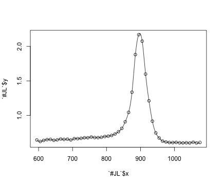

```
RObject{NilSxp}
NULL
```

```julia
using MATLAB, PyCall, RCall

mat"[$x, $y] = titanium"

interpolate = pyimport("scipy.interpolate")
f = interpolate.interp1d(vec(x), vec(y), kind="cubic")
new_x = LinRange(first(x), last(x), 1000)

R"""
plot($x, $y)
lines($new_x, $(f(new_x)))
"""
```

Calling DPPy

```
$ pip install dppy
```

```julia
using PyCall
FiniteDPP = pyimport("dppy.finite_dpps")[:FiniteDPP]

Φ = rand(5, 4)
L = Φ'*Φ

dpp = FiniteDPP("likelihood", projection=false, L=L)
dpp.sample_exact()
```

```
1-element Array{Int64,1}:
 1
```

## ScikitLearn in Julia

ScikitLearn.jl is a kind of "wrapper" for Python's `sklearn` package. [Blog post](https://medium.com/analytics-vidhya/machine-learning-with-julia-scikitlearn-jl-7c8cfe6076e8).

See also, [MLJ.jl](https://alan-turing-institute.github.io/MLJ.jl/dev/) from the Alan Turing Institute.

```julia
using RDatasets: dataset

iris = dataset("datasets", "iris");

X = convert(Array,
            iris[!, [:SepalLength, :SepalWidth, :PetalLength, :PetalWidth]])
y = convert(Array,
            iris[!, :Species])
```

```
150-element Array{String,1}:
 "setosa"
 "setosa"
 "setosa"
 "setosa"
 "setosa"
 "setosa"
 "setosa"
 "setosa"
 "setosa"
 "setosa"
 "setosa"
 "setosa"
 "setosa"
 ⋮
 "virginica"
 "virginica"
 "virginica"
 "virginica"
 "virginica"
 "virginica"
 "virginica"
 "virginica"
 "virginica"
 "virginica"
 "virginica"
 "virginica"
```

```julia
using ScikitLearn
@sk_import linear_model: LogisticRegression

model = LogisticRegression(fit_intercept=true, max_iter=200)

fit!(model, X, y)
score(model, X, y)
```

```
0.9733333333333334
```

## Benchmarking

```julia
using BenchmarkTools
σ(x) = 1 / (1 + exp(x))

X = rand(10_000)
@benchmark σ.($X)
```

```
BenchmarkTools.Trial:
  memory estimate:  78.20 KiB
  allocs estimate:  2
  --------------
  minimum time:     103.216 μs (0.00% GC)
  median time:      108.281 μs (0.00% GC)
  mean time:        155.595 μs (8.03% GC)
  maximum time:     11.944 ms (98.02% GC)
  --------------
  samples:          10000
  evals/sample:     1
```

## Parallel computing

Pretty simple

- [Julia documentation](https://docs.julialang.org/en/v1/manual/multi-threading/)
- Nice [blog post](https://techytok.com/lesson-parallel-computing/)

```julia
x = rand(10_000)
results = similar(x)
@btime for i in 1:length(x)
    results[i] = x[i]^2
end
```

```
  1.278 ms (48980 allocations: 921.58 KiB)
```

```julia
# Threads is in standard library
Threads.nthreads()
```

```
4
```

```julia
x = rand(10_000)
results = similar(x)
@btime begin
    Threads.@threads for i in 1:length(x)
        results[i] = x[i]^2
    end
end
```

```
  436.263 μs (39001 allocations: 611.88 KiB)
```

When working on a cluster, consider using

```julia
# using BenchmarkTools
using Distributed
addprocs(4)

@everywhere x = rand(100)
@everywhere f(x) = x^2

@btime pmap(f, x);
```

[output not shown]

# Reproducible research workflow

## Pipeline

- Autoreload code: [Revise.jl](https://timholy.github.io/Revise.jl/stable/)
- Create packages: [PkgTemplates.jl](https://invenia.github.io/PkgTemplates.jl/stable/)
- Managing packages: [Pkg.jl](https://julialang.github.io/Pkg.jl/v1/)
- Testing: [Test](https://docs.julialang.org/en/v1/stdlib/Test/)
- Documentation: [Documenter.jl](https://juliadocs.github.io/Documenter.jl/stable/)
- Continuous integration
  - [GitHubActions](https://docs.github.com/en/actions)
  - [Travis](https://github.com/travis-ci/docs-travis-ci-com/blob/master/user/languages/julia.md)
  - [Code coverage](https://github.com/JuliaCI/Coverage.jl): Codecov, Coveralls; integrates smoothly with Travis
- Benchmarking: BenchmarkTools.jl

## Package creation: a simple example

```
using PkgTemplates
t = Template(; user="github_user_name")
t("MyNewPackage")
```

# Take home message

## [Julia](https://julialang.org/) is

- **Easy to learn**
- **Quick and easy to develop in**
- **Runs like C but reads like Python/MATLAB**

> Culture of discipline about generic types and functions and abstraction

```
julia> Julia > Python > MATLAB
true
```

## Some ressources to get started

- All the links already given 🙃
- [Official documentation](https://docs.julialang.org/en/v1/)
- [Youtube Julia tutorials](https://www.youtube.com/playlist?list=PLP8iPy9hna6SCcFv3FvY_qjAmtTsNYHQE)
- [QuantEcon's Julia page](https://julia.quantecon.org/index_toc.html)